# Estudo de Caso 02: Comparação do IMC médio de alunos do PPGEE-UFMG ao longo de dois semestres

Autores: Danilo A. Caldeira Silva (Monitor), Fabiano Viana Oliveira da Cunha Médice (Relator), Fabrício Teixeira Coura (Coordenador) e Guilherme Lopes de Figueiredo Brandão (Verificador)

22 de Outubro de 2018

# Resumo

O presente trabalho aborda um experimento realizado para a comparação do IMC médio de duas populações de estudantes, sendo alunos da pós-graduação da UFMG nos semestres de 2016-2 e 2017-2. A coleta de dados foi realizada e disponibilizada pelo professor proponente da atividade e os dados foram obtidos do repositório do mesmo. Foi feita a filtragem das amostras e testadas de forma independente por sexo masculino e feminino. Foram definidas e testadas as hipóteses nula e alternativa, assim como a estimação do tamanho de efeito e do intervalo de confiança. Por fim, aborda-se a validação das premissas do teste e a derivação das conclusões apresentadas pelo experimento.

# O Experimento

O experimento elaborado consistiu, primeiramente, na obtenção do peso e altura das amostras de conveniência, neste caso, os alunos da disciplina Planejamento e Análise de Experimentos do programa de pós-graduação da UFMG nos semestres de 2016-2 e 2017-2. Estes dados foram obtidos e disponibilizados pelo professor em seu repositório do Github [1].

**Dados da Turma de 2016**

```
##    ID Course Gender Height.m Weight.kg
## 1   1  PPGEE      F     1.57      45.5
## 2   2  PPGEE      F     1.62      53.0
## 3   3  PPGEE      F     1.70      57.0
## 4   4  PPGEE      F     1.62      59.0
## 5   5  PPGEE      F     1.67      63.0
## 6   6  PPGEE      F     1.76      78.0
## 7   7  PPGEE      F     1.64      51.0
## 8   8  PPGEE      M     1.79      80.0
## 9   9  PPGEE      M     1.58      58.0
## 10 10  PPGEE      M     1.74      85.0
## 11 11  PPGEE      M     1.75     115.0
## 12 12  PPGEE      M     1.78      71.0
## 13 13  PPGEE      M     1.71      71.0
## 14 14  PPGEE      M     1.78      86.0
```

[output cut: 35 more lines]

**Dados Turma de 2017**

```
##    Weight.kg height.m Sex Age.years
## 1       89.0     1.73   M        23
## 2       72.5     1.64   M        28
## 3       84.0     1.70   M        34
## 4       90.0     1.72   M        27
## 5       60.0     1.70   M        33
## 6       79.0     1.80   M        27
## 7       80.4     1.84   M        24
## 8       65.0     1.70   M        25
## 9       88.0     1.88   M        31
## 10      64.0     1.69   M        27
## 11      53.0     1.66   M        39
## 12      60.0     1.84   M        29
## 13      78.0     1.76   M        36
## 14      86.0     1.71   M        32
## 15      49.0     1.68   F        23
## 16      54.0     1.61   F        24
## 17      48.0     1.64   F        24
## 18      46.0     1.61   F        31
## 19      68.0     1.71   M        31
## 20      74.0     1.68   M        26
## 21      69.0     1.76   M        23
## 22      63.0     1.65   M        22
## 23      78.0     1.83   M        33
## 24      60.2     1.70   M        25
## 25      71.0     1.70   M        27
```

Inicialmente, tendo em vista que os dados disponibilizados estão em formatos diferentes e que o arquivo relativo a turma 2016-2 apresenta, também, dados de alunos de graduação, foi realizada uma preparação dos dados, de forma a obter apenas os valores referentes a alunos da pós-graduação.

**Dados da Turma de 2016 Filtrados**

```
##    ID Course Gender Height.m Weight.kg
## 1   1  PPGEE      F     1.57      45.5
## 2   2  PPGEE      F     1.62      53.0
## 3   3  PPGEE      F     1.70      57.0
## 4   4  PPGEE      F     1.62      59.0
## 5   5  PPGEE      F     1.67      63.0
## 6   6  PPGEE      F     1.76      78.0
## 7   7  PPGEE      F     1.64      51.0
## 8   8  PPGEE      M     1.79      80.0
## 9   9  PPGEE      M     1.58      58.0
## 10 10  PPGEE      M     1.74      85.0
## 11 11  PPGEE      M     1.75     115.0
## 12 12  PPGEE      M     1.78      71.0
## 13 13  PPGEE      M     1.71      71.0
## 14 14  PPGEE      M     1.78      86.0
## 15 15  PPGEE      M     1.81      80.0
## 16 16  PPGEE      M     1.79      72.0
## 17 17  PPGEE      M     1.70      62.5
## 18 18  PPGEE      M     1.82     100.0
## 19 19  PPGEE      M     1.72      52.0
## 20 20  PPGEE      M     1.83      84.0
## 21 21  PPGEE      M     1.70      74.0
## 22 22  PPGEE      M     1.83      92.0
## 23 23  PPGEE      M     1.73      60.0
## 24 24  PPGEE      M     1.69      57.5
## 25 25  PPGEE      M     1.89      87.0
## 26 26  PPGEE      M     1.63      81.0
## 27 27  PPGEE      M     1.81      78.0
## 28 28  PPGEE      M     1.73      68.0
```

Em posse dos valores de Altura e Peso, foi realizado o cálculo do ICM, gerando uma nova coluna nos dados. O IMC é calculado por $IMC=Peso/Altura^2$.

**Dados da Turma de 2016**

```
##    ID Course Gender Height.m Weight.kg   IMC
## 1   1  PPGEE      F     1.57      45.5 18.46
## 2   2  PPGEE      F     1.62      53.0 20.20
## 3   3  PPGEE      F     1.70      57.0 19.72
## 4   4  PPGEE      F     1.62      59.0 22.48
## 5   5  PPGEE      F     1.67      63.0 22.59
## 6   6  PPGEE      F     1.76      78.0 25.18
## 7   7  PPGEE      F     1.64      51.0 18.96
## 8   8  PPGEE      M     1.79      80.0 24.97
## 9   9  PPGEE      M     1.58      58.0 23.23
## 10 10  PPGEE      M     1.74      85.0 28.08
## 11 11  PPGEE      M     1.75     115.0 37.55
## 12 12  PPGEE      M     1.78      71.0 22.41
## 13 13  PPGEE      M     1.71      71.0 24.28
## 14 14  PPGEE      M     1.78      86.0 27.14
## 15 15  PPGEE      M     1.81      80.0 24.42
## 16 16  PPGEE      M     1.79      72.0 22.47
## 17 17  PPGEE      M     1.70      62.5 21.63
## 18 18  PPGEE      M     1.82     100.0 30.19
## 19 19  PPGEE      M     1.72      52.0 17.58
## 20 20  PPGEE      M     1.83      84.0 25.08
## 21 21  PPGEE      M     1.70      74.0 25.61
## 22 22  PPGEE      M     1.83      92.0 27.47
## 23 23  PPGEE      M     1.73      60.0 20.05
## 24 24  PPGEE      M     1.69      57.5 20.13
## 25 25  PPGEE      M     1.89      87.0 24.36
## 26 26  PPGEE      M     1.63      81.0 30.49
## 27 27  PPGEE      M     1.81      78.0 23.81
## 28 28  PPGEE      M     1.73      68.0 22.72
```

**Dados Turma de 2017**

```
##    Weight.kg height.m Sex Age.years   IMC
## 1       89.0     1.73   M        23 29.74
## 2       72.5     1.64   M        28 26.96
## 3       84.0     1.70   M        34 29.07
## 4       90.0     1.72   M        27 30.42
## 5       60.0     1.70   M        33 20.76
## 6       79.0     1.80   M        27 24.38
## 7       80.4     1.84   M        24 23.75
## 8       65.0     1.70   M        25 22.49
## 9       88.0     1.88   M        31 24.90
## 10      64.0     1.69   M        27 22.41
## 11      53.0     1.66   M        39 19.23
## 12      60.0     1.84   M        29 17.72
## 13      78.0     1.76   M        36 25.18
## 14      86.0     1.71   M        32 29.41
## 15      49.0     1.68   F        23 17.36
## 16      54.0     1.61   F        24 20.83
## 17      48.0     1.64   F        24 17.85
## 18      46.0     1.61   F        31 17.75
## 19      68.0     1.71   M        31 23.26
## 20      74.0     1.68   M        26 26.22
## 21      69.0     1.76   M        23 22.28
## 22      63.0     1.65   M        22 23.14
## 23      78.0     1.83   M        33 23.29
## 24      60.2     1.70   M        25 20.83
## 25      71.0     1.70   M        27 24.57
```

Após a organização dos dados, realizou-se uma análise exploratória, afim de identificar possíveis *outliers*, assimetrias ou outras peculiaridades. A Figura 1 e a Figura 2 apresentam os *boxplot* dos dados obtidos para a turma 2016-2 e 2017-2, respectivamente. Observa-se que a turma 2016-2 apresenta um *outlier*.

**Figura 1 - Boxplot do IMC da Turma 2016**

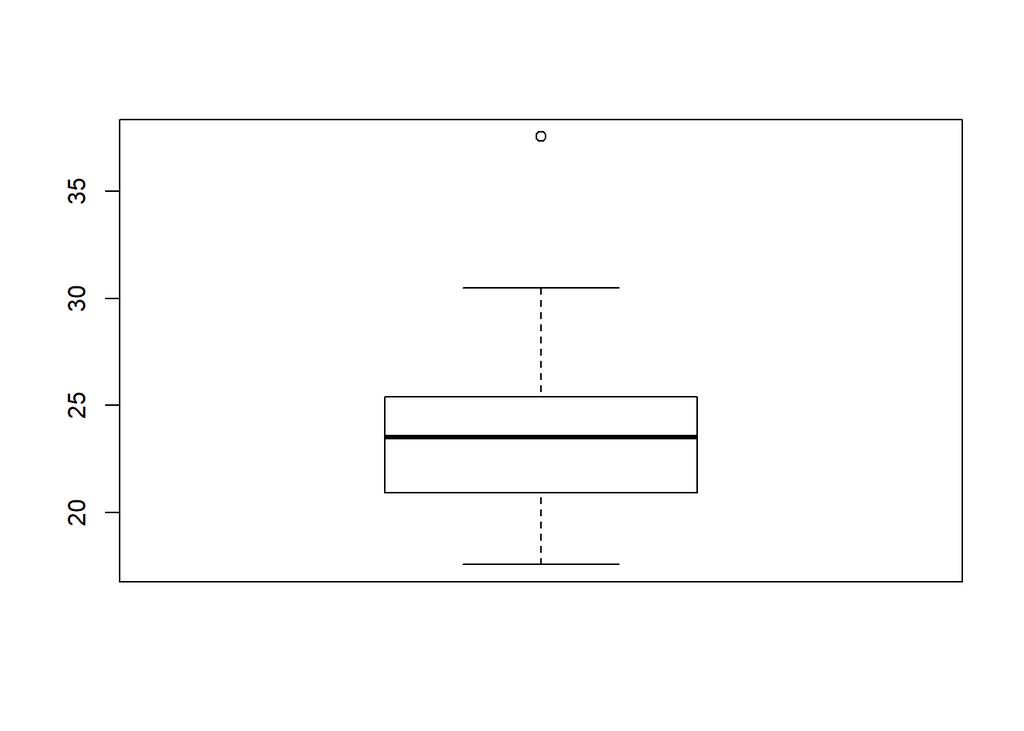

**Figura 2 - Boxplot do IMC da Turma 2017**

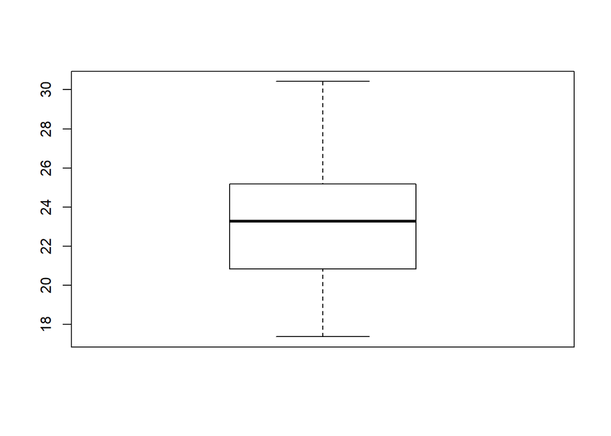

Posteriormente, foram obtidos os histogramas das amostras, conforme apresentados nas Figuras 3 e 4. Visualmente, os dados de IMC da turma 2017 apresenta normalidade, enquanto os da turma 2016 apresentam uma cauda mais pesada à direita.

**Figura 3 - Histograma do IMC da Turma 2016**

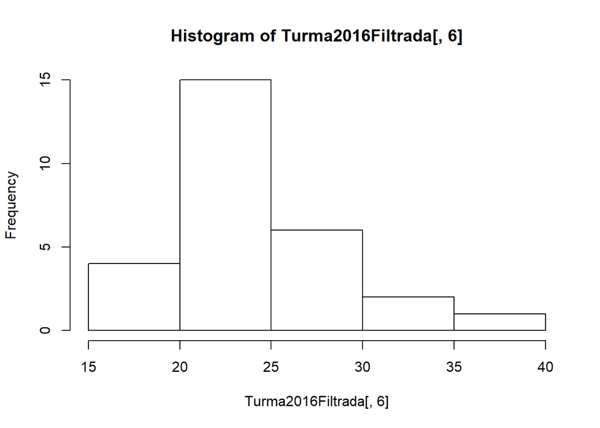

**Figura 4 - Histograma do IMC da Turma 2017**

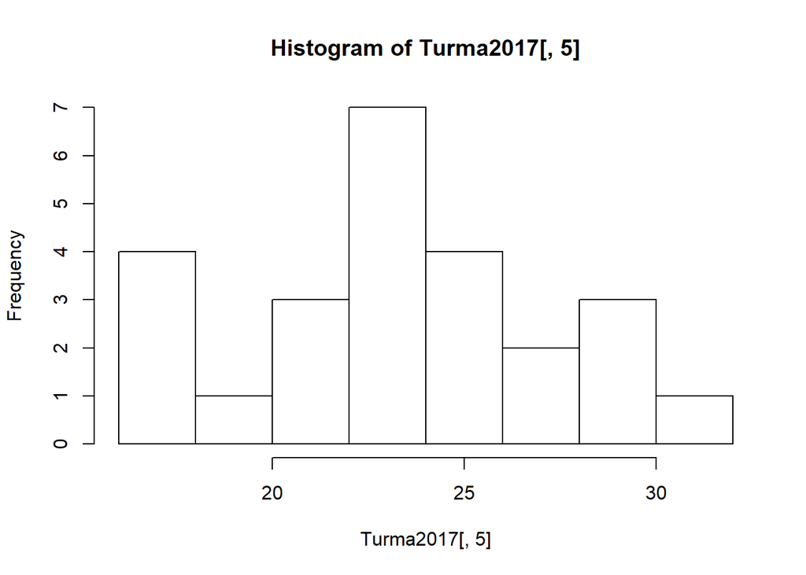

Executou-se, então, o teste de Shapiro-Wilk de normalidade [2]. Os resultados do teste estão mostrados no *output* abaixo:

```
##
##  Shapiro-Wilk normality test
##
## data:  Turma2016Filtrada[, 6]
## W = 0.92186, p-value = 0.03858
```

```
##
##  Shapiro-Wilk normality test
##
## data:  Turma2017[, 5]
## W = 0.95379, p-value = 0.3047
```

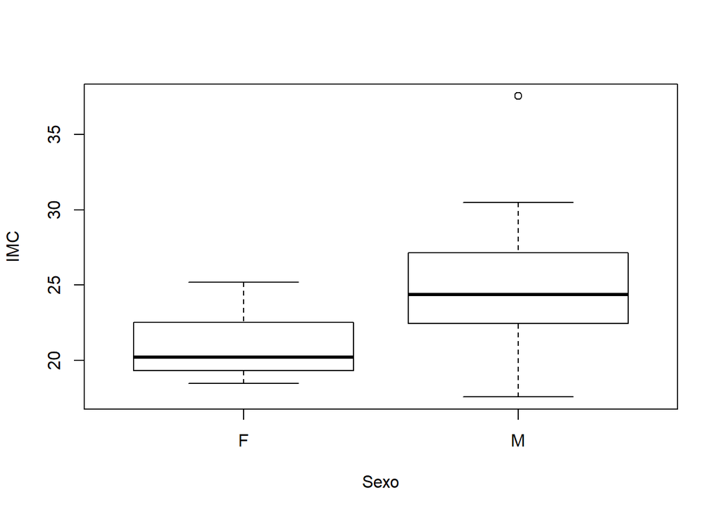

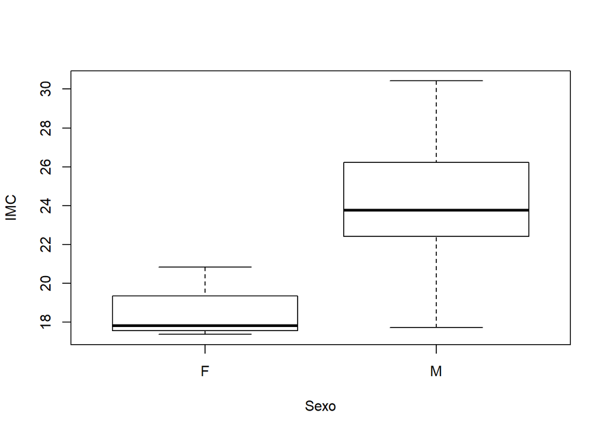

Após analisar os gráficos, a separação por sexo se viu necessaria para a correta analise dos dados. Assim, realizou-se a análise exploratória de normalidade dos dados, considerando-se a divisão por sexo de cada turma, aplicando-se o teste de normalidade de Shapiro-Wilk e a análise dos gráficos quantil-quantil. Os resultados são apresentados nos *outputs*:

```
##
##  Shapiro-Wilk normality test
##
## data:  F2016[, 6]
## W = 0.91987, p-value = 0.4684
```

**Figura 7 - Gráfico Quantil-Quantil das Mulheres da Turma 2016**

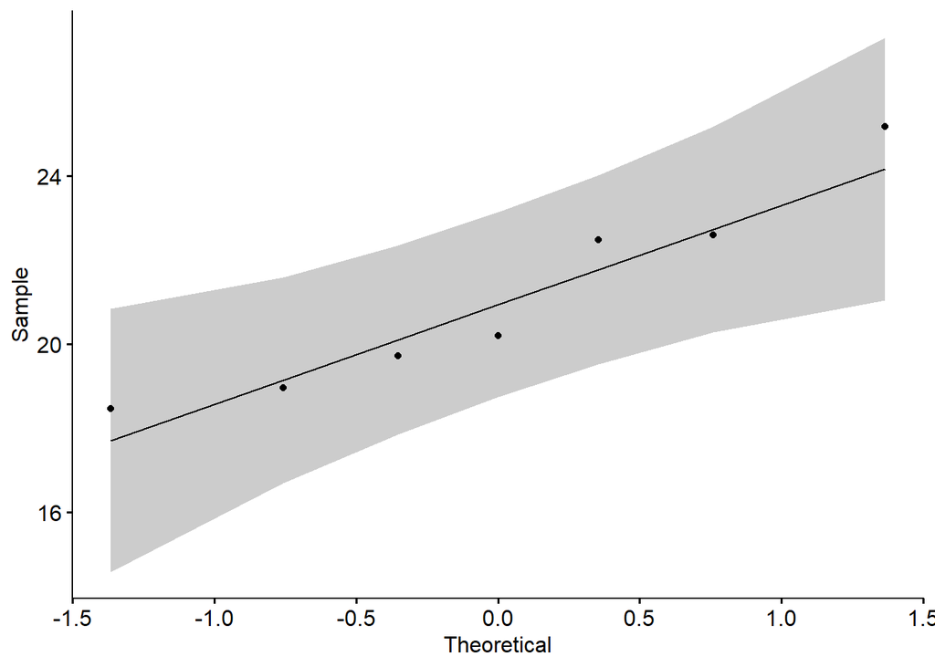

Pelo o valor do Teste Shapiro Wilk e pelo a figura 7, percebe-se que os dados são normais.

```
##
##  Shapiro-Wilk normality test
##
## data:  M2016[, 6]
## W = 0.92835, p-value = 0.1275
```

**Figura 8 - Gráfico Quantil-Quantil dos Homens da Turma 2016**

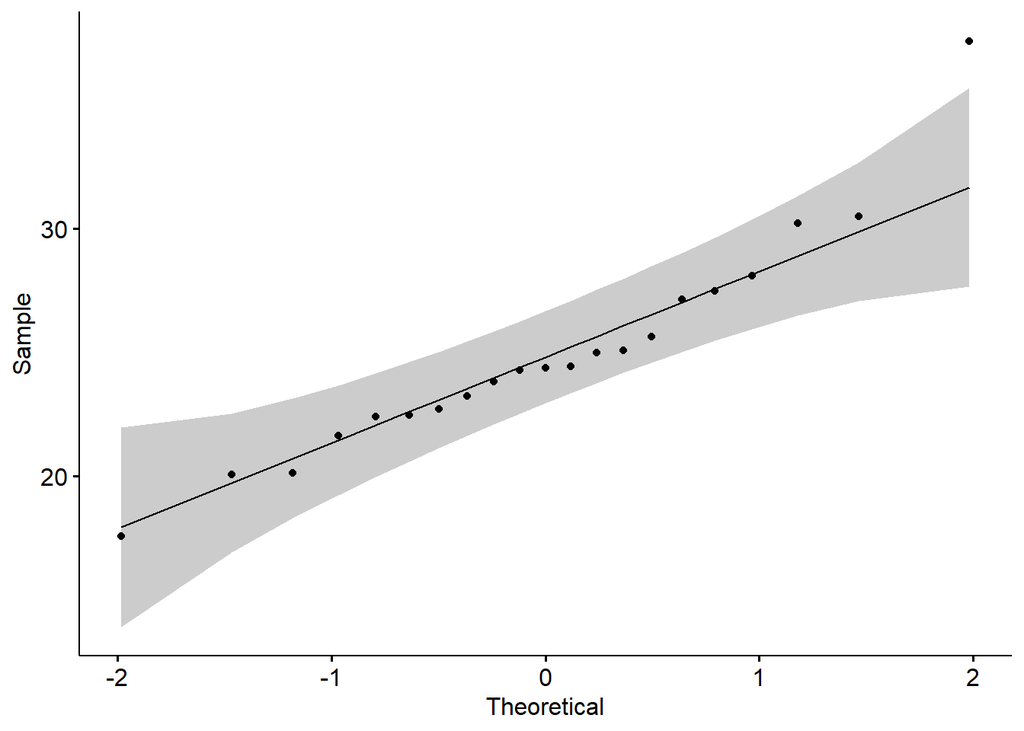

Pelo o valor do Teste Shapiro Wilk e pelo a figura 8, percebe-se que os dados são normais, apesar de haver um outlier que puxa a amostra para não normalidade.

```
##
##  Shapiro-Wilk normality test
##
## data:  F2017[, 5]
## W = 0.74871, p-value = 0.03756
```

**Figura 9 - Gráfico Quantil-Quantil das Mulheres da Turma 2017**

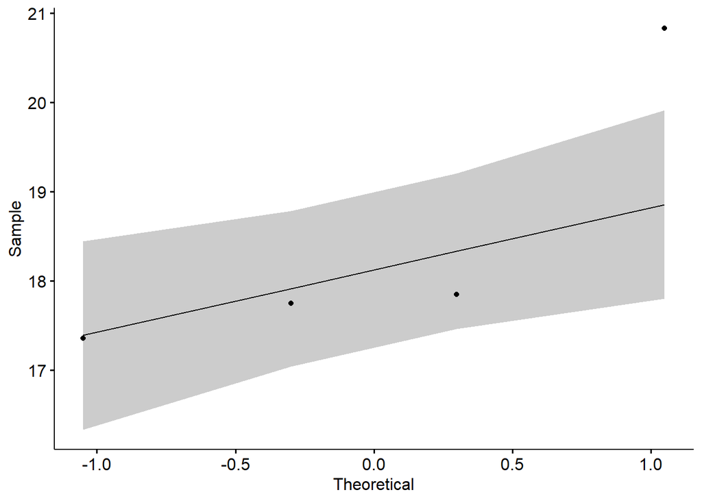

Pelo o valor do Teste Shapiro Wilk e pelo a figura 9, percebe-se que os dados não são normais. Por haver apenas 4 observaçõeso outlier que puxa a amostra para não normalidade e a sensibilidade do teste fica alta para cada observação na amostra.

```
##
##  Shapiro-Wilk normality test
##
## data:  M2017[, 5]
## W = 0.96488, p-value = 0.6192
```

**Figura 10 - Gráfico Quantil-Quantil dos Homens da Turma 2017**

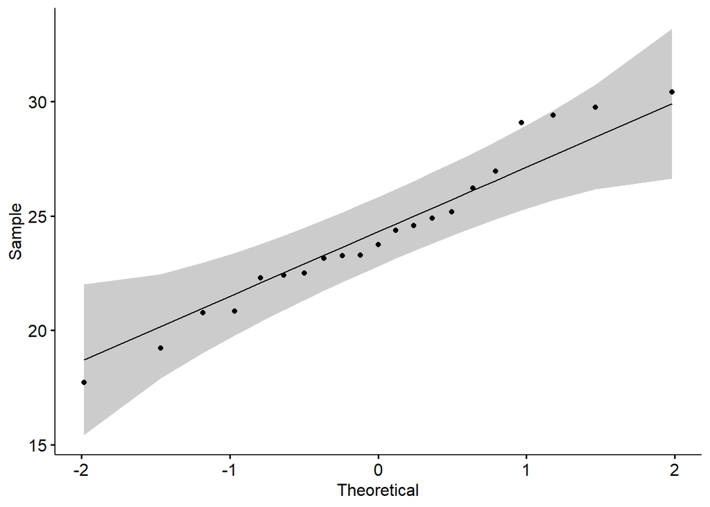

Pelo o valor do Teste Shapiro Wilk e pelo a figura 10, percebe-se que os dados são normais.

# Comparação Estatística das Salas

A fim de se escolher o nível de confiança do teste T, utilizou-se o cálculo de potência para definir qual teria o menor erro do Tipo II. Como o grupo de mulheres da turma de 2017 possuem apenas 4 observações, ele possuíra a menor potencia e será a maior fonte de incerteza do teste. Assim, foi realizado o cálculo de potência para $\alpha$ = 0.95 e $\alpha$ = 0.99.

```
##
##      Two-sample t test power calculation
##
##               n = 4
##           delta = 1
##              sd = 1
##       sig.level = 0.01
##           power = 0.06593159
##     alternative = two.sided
##
## NOTE: n is number in *each* group
```

```
##
##      Two-sample t test power calculation
##
##               n = 4
##           delta = 1
##              sd = 1
##       sig.level = 0.05
##           power = 0.2224633
##     alternative = two.sided
##
## NOTE: n is number in *each* group
```

Assim, a potência será maior para $\alpha$ = 0.95 e o mesmo nível de significancia será usado para os testes T a seguir.

Como em ambas as turmas possuem 21 observações, a potência do teste t será:

```
##
##      Two-sample t test power calculation
##
##               n = 21
##           delta = 1
##              sd = 1
##       sig.level = 0.05
##           power = 0.8852576
##     alternative = two.sided
##
## NOTE: n is number in *each* group
```

Ao comparar a salas, espera-se que a diferença entre as mulheres de cada sala seja zero. Então:

$$\begin{cases} H_0: \mu_1 - \mu_2 = 0 & \\ H_1: \mu_1 - \mu_2 \neq 0\end{cases}$$

```
##
##  Welch Two Sample t-test
##
## data:  F2016[, 6] and F2017[, 5]
## t = 2.1704, df = 8.6009, p-value = 0.05945
## alternative hypothesis: true difference in means is not equal to 0
## 95 percent confidence interval:
##  -0.1310754  5.4046469
## sample estimates:
## mean of x mean of y
##  21.08429  18.44750
```

Ao comparar a salas, espera-se que a diferença entre os homems de cada sala seja zero. Então:

$$\begin{cases} H_0: \mu_1 - \mu_2 = 0 & \\ H_1: \mu_1 - \mu_2 \neq 0\end{cases}$$

```
##
##  Welch Two Sample t-test
##
## data:  M2016[, 6] and M2017[, 5]
## t = 0.53978, df = 38.061, p-value = 0.5925
## alternative hypothesis: true difference in means is not equal to 0
## 95 percent confidence interval:
##  -1.788951  3.089904
## sample estimates:
## mean of x mean of y
##  24.93667  24.28619
```

# Análise dos resultados

Por cada observação ser de um aluno, não há dependência das variáveis, pois cada indivíduo é único.

Por ter pouca observação na amostra das mulheres de cada turma, não se tem uma grande potência do teste t, não obtendo assim grande confiança nos dados. Assim, escolheu-se um nível de confiancia de 95% entre 95% e 99% por ter uma potência de 22% para as 4 observações em relação a potencia de 6% para o para o nível de confiancia de 99%.

De acordo com o teste t, tem-se que a diferença entre as médias de ICM das mulheres de cada turma é 0 [-0.1310754,5.4046469] para a significancia de 95% com uma potência de 22%. Mesmo que a amostra de mulheres da turma de 2017 não seja normal, por apenas ter 4 observações, qualquer pequena variação faz com que a sensibilidade do teste aponte para a não normalidade. Assim, como mostra a figura do Quantile-Quantile plot, há apenas um ponto afastado da curva que leva a amostra a não ser normal.

Em relação a média de IMC dos homens, de acordo com o teste t, tem-se que a diferença de cada turma é 0 [-1.788951 3.089904] para a significancia de 95% com uma potência de 88%.

## Conclusões

De acordo com os resultados do teste t e da analise dos dados, há diferença entre o ICM de homens e mulheres, porém não há diferença em média entre o IMC dos homens de cada turma e o IMC das mulheres de cada turma.

## Referências

[1] Felipe Campelo (2018), Lecture Notes on Design and Analysis of Experiments. Online: http://git.io/v3Kh8 Version 2.12; Creative Commons BY-NC-SA 4.0.

[2] Portal Action. Teste de Shapiro-Wilk. Disponível em: http://www.portalaction.com.br/inferencia/64-teste-de-shapiro-wilk Acesso em: 22 de Outubro de 2018.

[3] Montgomery, Douglas C. Applied statistics and probability for engineers / Douglas C. Montgomery, George C. Runger.Ã¢, 6th ed.